A few days back in a discussion someone pointed that phone heights have started to shrink again after continuous increase from last 10 odd years. But he could not back up that with data. For few days, I was searching for a reason to deep dive into large data pool and I got a purpose- Verify the cellphone height myth.

### Few Words on the Data

To solve the challenge, first I needed a data source that is reliable and have historical data. In this case, the choice was easy- [GSMArena](http://www.gsmarena.com/) is the defacto source of all things mobile.

But I also wanted to add logos for each brand and for some odd reason GSMArena removed the logos which used to be in their all brands page.So, I have to resort to another source- [Gadget360](http://gadgets.ndtv.com/mobiles/all-brands?site=classic). Though, I ended up deciding not to add logos due to huge page loading times, I think they should get a mentioned.

> We ended up with **8,653 entries** (All there is to have during July’2017) containing brand, device name and dimensions

So, with source finalized the data scraping started and after 3-4 days of scraping and refining codes and scraping again , we ended up with **8,653 entries** (The number of GSMArena device during 2nd Week of July) containing brand, device name and dimensions.

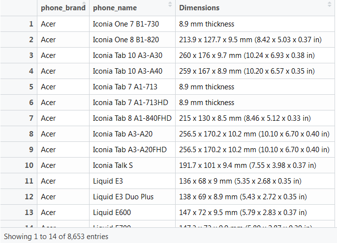

As you can see from above, some columns don’t have height and smartwatches appear in the device list. During data cleaning, we ended up excluding entries without proper dimension data and excluded (most) smartwatches and wearables by leading manufacturers (Galaxy Gears, Apple Watches etc.). After cleansing data, we ended up with **6,442 valid entries** .

> After cleansing data, we ended up with **6,442 valid entries** for the analysis data set

### All on a Scatter

The result of plotting all those devices in a scatter diagram is below. For additional insights, I decided to differentiate industry movers in different eras (Nokia, Apple and Samsung) to explore whether they give some insights. For better clarity, you can check the interactive version of the chart here- [Phone Height in Time](https://jotayu.com/tech/2017/08/18/Phone_Height_Large/) (Note: page may take some time to load due to complex nature of the chart).

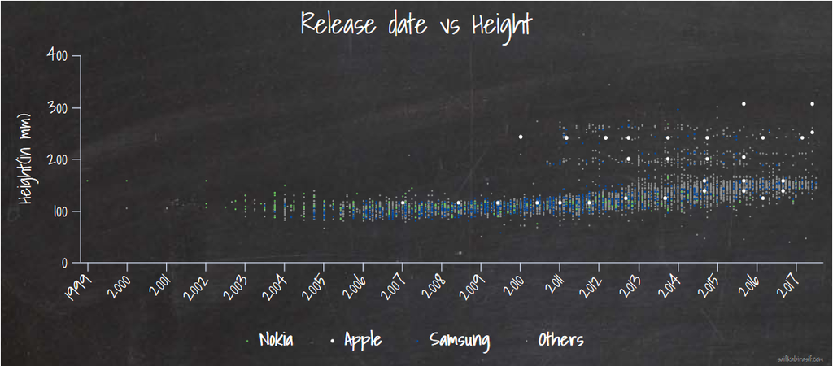

> Until 2010, phones had a fairly standard height but in years after that height standards have been decoupled into three distinctive streams

It is apparent that until 2010, phones had a fairly standard height but in years after that height standards have been decoupled into three distinctive streams- Tablets, Phablets and good old “no-lets” phones.

### Back to Problem Statement

It seems, We are swaying away from the problem statement. So, let’s see whether mean height of phone are increasing or decreasing? It is increasing as apparent from the following column chart. In fact, the increase in 2017 (so far) is highest in last 3-4 years.

[interactive chart not shown]

> Increase in 2017 (so far) is highest in last 3-4 years

### Apple is Apple for a Reason

Now that, the investigation on problem statement is done and dusted. Let’s see if we can find any by-products.

From iPhones humble start in 2007, Apple seems to march against the tide and ultimately come out on top. It is no different in terms of phone height- Apple devices are always outliers as can be seen below.

[interactive chart not shown]

But it seems Apple’s limited releases are skewing the result in their favour with all those iPads. Excluding iPads, Tablets and Galaxy Notes result in the following result which is more in line with public belief.

[interactive chart not shown]

> Now in 2017, it seems all are converging to a single point that 150mm may be the sweetest spot in terms of phone height

In its initial year (2007-10), Apple produced phones that are more than 8% larger than industry. Then, the industry caught up with Apple in following years and Samsung went the way of Apple in initial year - Playing the outlier.

Now in 2017, it seems all are converging to a single point that 150mm may be the sweetest spot in terms of phone height.

Note that, Apple is missing in year 2017 because at the time of writing(August) Apple did not release any phone (they released iPads so far). But if the [rumours](https://9to5mac.com/2017/05/30/iphone-8-dimensions-size-comparison/) are true, iPhone 8 and its Plus version will have heights of 143 and 158mm respectively keeping the mean at around the sweet 150mm.

### End Notes

Up to August 2017, there is no sign that phone heights will become smaller. But as can be seen from the last graph, market behemoths Samsung and Apple has started decreasing mean height of their phones. So may be in 3-4 years, we may witness phones becoming smaller again and the circle will be full.

That’s it for today. Stay tuned and keep on commenting and sharing your views.

You can catch up with my analysis series on gaming industry in the following links:

> - Playstation-4 -[PS4 in Numbers](https://saifkabirasif.com/2017/06/29/Meta_PS4/)
> - XBox One -[Numbers](https://saifkabirasif.com/2017/07/14/Meta_XBO/) ; [Developers](https://saifkabirasif.com/2017/07/15/XBO_Devs/)
> - Wii U -[Numbers](https://saifkabirasif.com/2017/07/19/Meta_WiiU/) ; [Developers](https://saifkabirasif.com/2017/07/22/WiiU_Devs/)
> - Genre Diversity -[PS4](https://saifkabirasif.com/2017/07/31/Diversity_PS4/) ; [XBox One](https://saifkabirasif.com/2017/08/04/Diversity_XBO/)

If you got a data-related challenge worth solving, you can knock me in the links mentioned in profile section and may be we can help each other out.